# An Exploratory Data Analysis of COVID-19 in Belgium

D.K.H.Colombage - AS2021464

# 1.Introduction

Belgium, officially the Kingdom of Belgium, is a country in Northwestern Europe. The country is bordered by the Netherlands to the north, Germany to the east, Luxembourg to the southeast, France to the south, and the North Sea to the west. It covers an area of 30,689 km2 (11,849 sq mi) and has a population of more than 11.7 million,making it the 22nd most densely populated country in the world and the 6th most densely populated country in Europe, with a density of 383/km2 (990/sq mi). Belgium is part of an area known as the Low Countries, historically a somewhat larger region than the Benelux group of states, as it also included parts of northern France. The capital and largest metropolitan region is Brussels; other major cities are Antwerp, Ghent, Charleroi, Liège, Bruges, Namur, and Leuven. Belgium has a mixed economic system which includes a private-enterprise system, combined with centralized economic planning, and government regulation.

# 2.Exploratory Data Analysis

## 2.1 Structure of Data

The dataset contains the daily summary of Coronavirus cases worldwide. All cases are recorded according to the following format

- date : Date in YYYY-MM-DD
- province : Name of province/state, for countries where data is provided split across multiple provinces/states.
- country : Name of country/region.
- lat : Latitude of center of geographic region, defined as either country or, if available, province.
- long : Longitude of center of geographic region, defined as either country or, if available, province.
- type : An indicator for the type of cases (confirmed, death, recovered).
- cases : Number of cases on given date.
- uid : Country code
- iso2 : Officially assigned country code identifiers with two-letter
- iso3 : Officially assigned country code identifiers with three-letter
- code3 : UN country code
- combined_key : Country and province (if applicable)
- population : Country or province population
- continent_name : Continent name
- continent_code : Continent code

**Source** : Johns Hopkins University Center for Systems Science and Engineering (JHU CCSE) Coronavirus website.

**Summary of Dataset**

```
      date              province           country               lat
 Min.   :2020-01-22   Length:3429        Length:3429        Min.   :50.83
 1st Qu.:2020-11-02   Class :character   Class :character   1st Qu.:50.83
 Median :2021-08-15   Mode  :character   Mode  :character   Median :50.83
 Mean   :2021-08-15                                         Mean   :50.83
 3rd Qu.:2022-05-28                                         3rd Qu.:50.83
 Max.   :2023-03-09                                         Max.   :50.83
      long          type               cases             uid
 Min.   :4.47   Length:3429        Min.   :     0   Min.   :56
 1st Qu.:4.47   Class :character   1st Qu.:     0   1st Qu.:56
 Median :4.47   Mode  :character   Median :     0   Median :56
 Mean   :4.47                      Mean   :  1401   Mean   :56
 3rd Qu.:4.47                      3rd Qu.:   120   3rd Qu.:56
 Max.   :4.47                      Max.   :133480   Max.   :56
     iso2               iso3               code3    combined_key
 Length:3429        Length:3429        Min.   :56   Length:3429
 Class :character   Class :character   1st Qu.:56   Class :character
 Mode  :character   Mode  :character   Median :56   Mode  :character
                                       Mean   :56
                                       3rd Qu.:56
                                       Max.   :56
   population       continent_name     continent_code
 Min.   :11589616   Length:3429        Length:3429
 1st Qu.:11589616   Class :character   Class :character
 Median :11589616   Mode  :character   Mode  :character
 Mean   :11589616
 3rd Qu.:11589616
 Max.   :11589616
```

## 2.2 Analysis of Death, Confirmed, Recovered Cases

### 2.2.1 Confirmed COVID-19 Cases

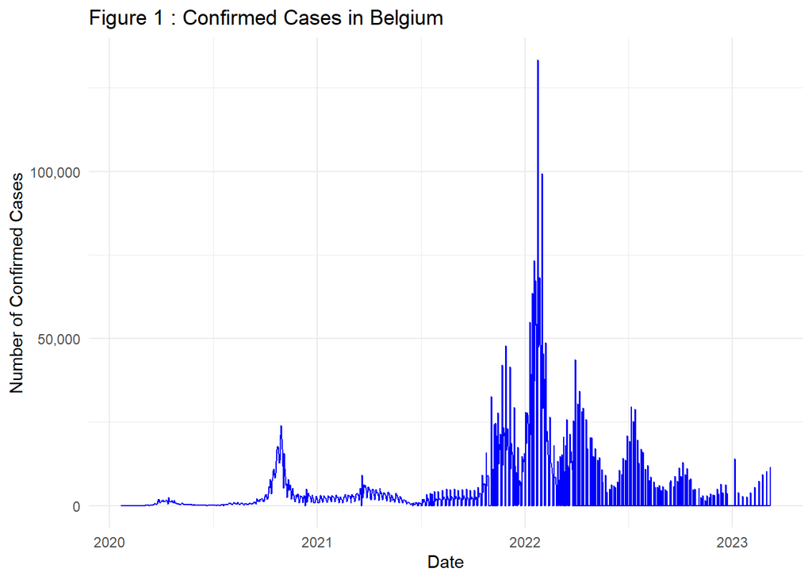

This chart shows the trend of confirmed COVID-19 cases in Belgium over time. The x-axis represents the date, spanning from 2020 to 2023, while the y-axis shows the number of confirmed cases.

**Early 2020** : The cases were low at the beginning of the pandemic.

**Mid-2020 to 2021**: There were noticeable spikes in cases, indicating waves of increased infection rates.

**Peak in Early 2022**: The highest spike occurred around the beginning of 2022, reflecting a significant surge in cases, likely due to the spread of a new variant.

**Post-2022**: After the peak, the number of cases fluctuated, with smaller spikes, but remained lower compared to the peak.

This pattern indicates the different waves of COVID-19 infections in Belgium, with the largest wave occurring in early 2022. And following table shows aboout numeric values in confirmed cases in Belgium

Table 1: summary of confirmed cases in Belgium

|  | date | cases |
| --- | --- | --- |
|  | Min. :2020-01-22 | Min. : 0 |
|  | 1st Qu.:2020-11-02 | 1st Qu.: 0 |
|  | Median :2021-08-15 | Median : 784 |
|  | Mean :2021-08-15 | Mean : 4146 |
|  | 3rd Qu.:2022-05-27 | 3rd Qu.: 3423 |
|  | Max. :2023-03-09 | Max. :133480 |

### 2.2.2 Death COVID-19 Cases

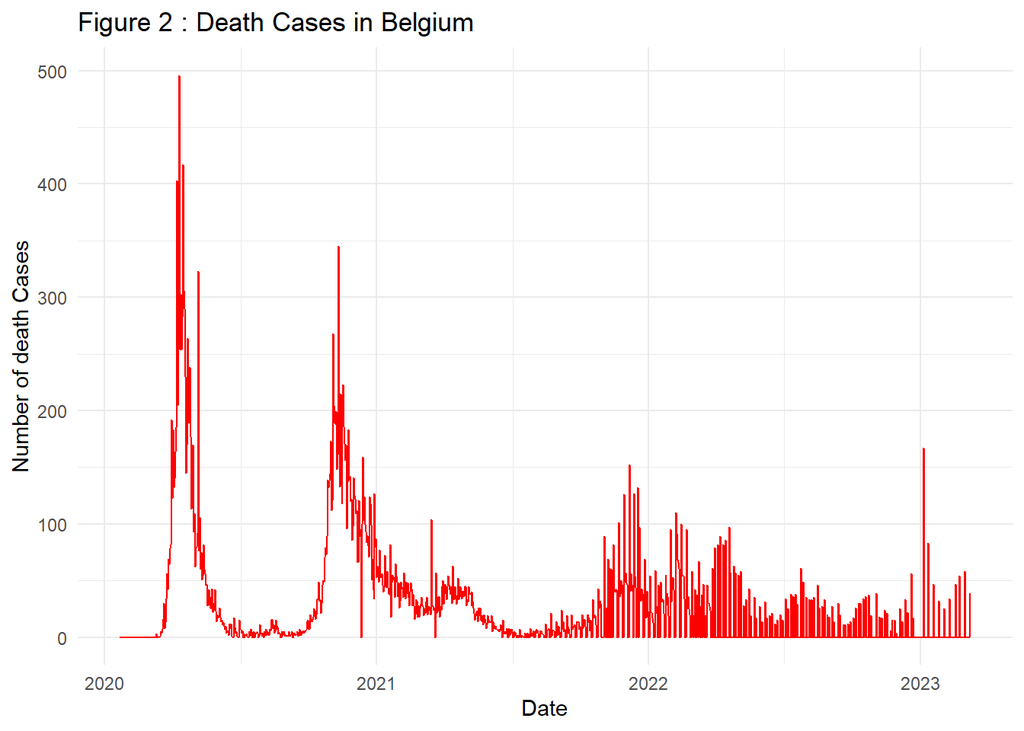

Above figure shows the number of COVID-19 deaths in Belgium from 2020 to early 2023. In early 2020, there was a big spike with nearly 500 deaths in one day, marking the first major wave of the pandemic. After this peak, the number of deaths dropped but rose again in late 2020 and early 2021 during other waves. From 2021 to 2022, there were smaller waves with fewer deaths compared to the first wave. By early 2023, the number of daily deaths became more stable, but there were still occasional increases.

Table 2: summary of death cases in Belgium

|  | date | cases |
| --- | --- | --- |
|  | Min. :2020-01-22 | Min. : 0.00 |
|  | 1st Qu.:2020-11-02 | 1st Qu.: 0.00 |
|  | Median :2021-08-15 | Median : 7.00 |
|  | Mean :2021-08-15 | Mean : 29.69 |
|  | 3rd Qu.:2022-05-27 | 3rd Qu.: 37.00 |
|  | Max. :2023-03-09 | Max. :496.00 |

### 2.2.2 Recovery COVID-19 Cases

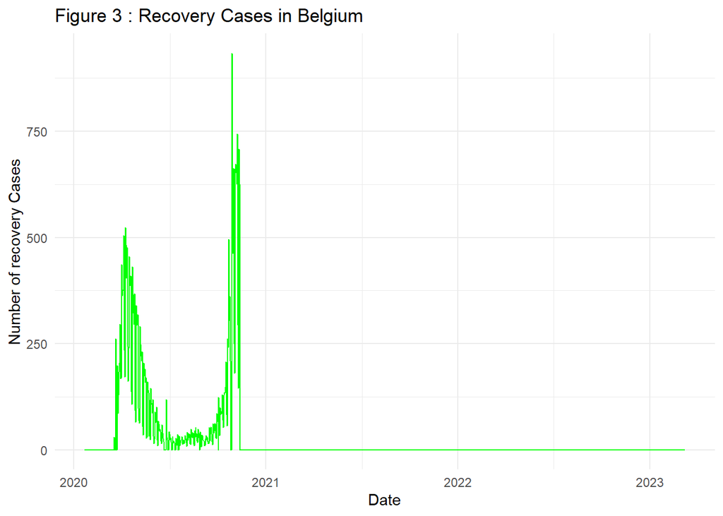

Table 3: summary of Recovery cases in Belgium

|  | date | cases |
| --- | --- | --- |
|  | Min. :2020-01-22 | Min. : 0.00 |
|  | 1st Qu.:2020-11-02 | 1st Qu.: 0.00 |
|  | Median :2021-08-15 | Median : 0.00 |
|  | Mean :2021-08-15 | Mean : 27.31 |
|  | 3rd Qu.:2022-05-27 | 3rd Qu.: 0.00 |
|  | Max. :2023-03-09 | Max. :934.00 |

### 2.2.3 Comparison in Belgium

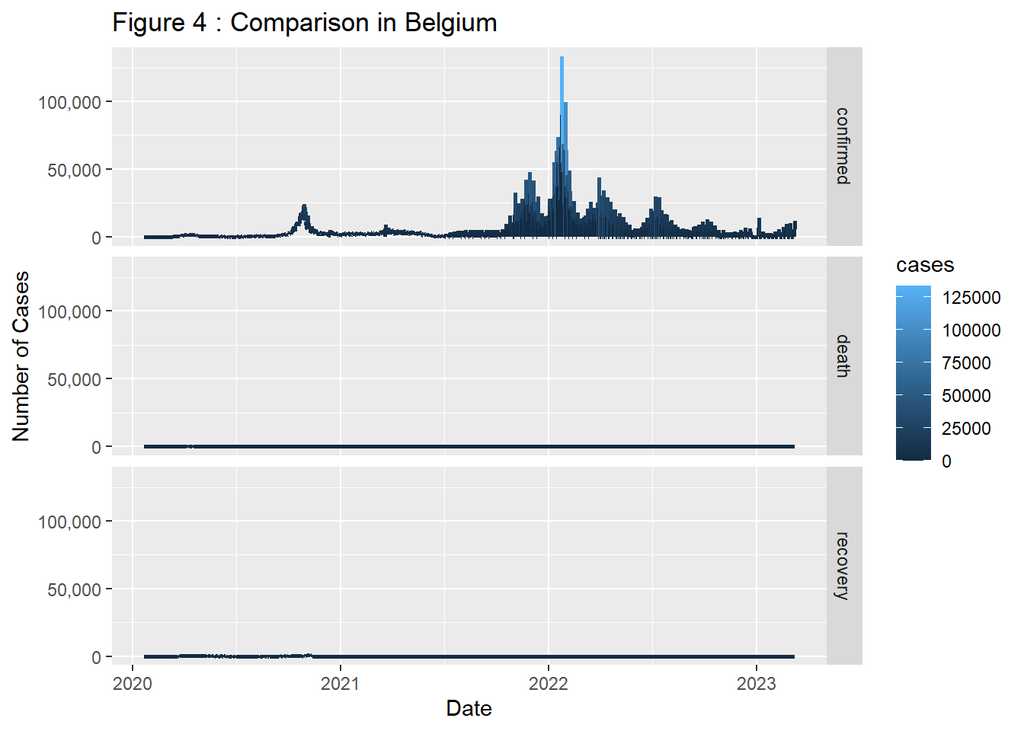

This chart shows the trends in confirmed COVID-19 cases, deaths, and recoveries from 2020 to 2023. The top panel indicates the number of confirmed cases, which peaked significantly in early 2022. The middle panel shows the number of deaths, and the bottom panel represents the number of recoveries. Although the death and recovery figures are not zero, they appear very low compared to the confirmed cases. To better understand the trends for all three metrics (confirmed cases, deaths, and recoveries) simultaneously, the next chart will use a logarithmic scale. This approach will help in visualizing and comparing these different scales more effectively.

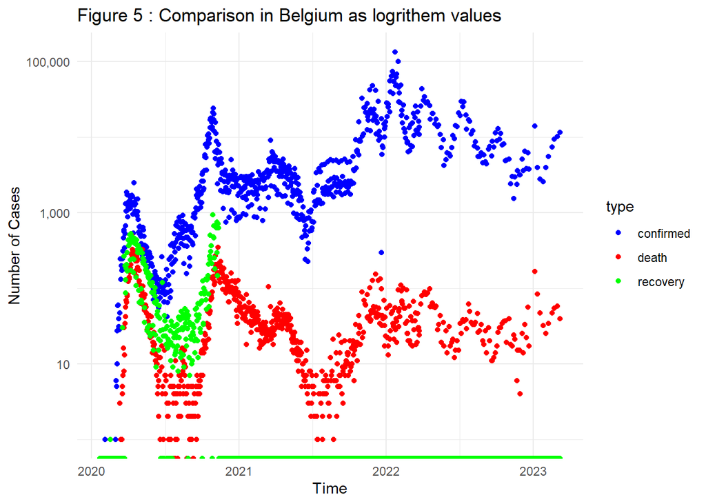

This figure uses a logarithmic scale to show the trends in confirmed COVID-19 cases, deaths, and recoveries in Belgium over time. By applying the log function, the chart makes it easier to compare these data points, even though they vary greatly in magnitude.

The blue dots represent confirmed cases, which are consistently higher than the other two metrics. The red dots show deaths, and the green dots indicate recoveries. In the beginning, around 2020, all three metrics had similar values. However, as time progresses, the number of confirmed cases significantly increases compared to deaths and recoveries.

The logarithmic scale helps to visualize all three metrics on the same graph, revealing patterns that are not as obvious in a standard scale. For instance, while confirmed cases show a large spike and higher variability, deaths and recoveries remain relatively lower and more stable. This way, we can see the relative changes and trends of confirmed cases, deaths, and recoveries more clearly over the period from 2020 to 2023.

## 2.3 Active Cases in Belgium

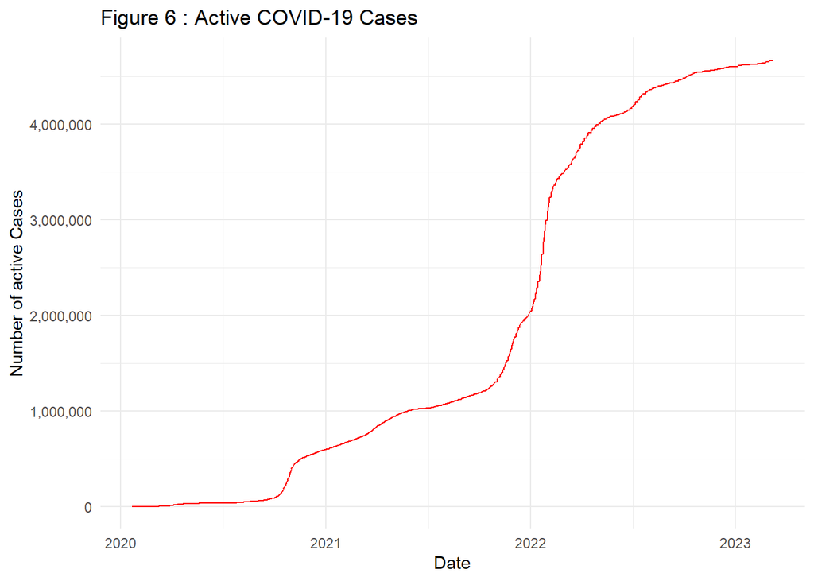

This chart shows the number of active COVID-19 cases in Belgium from 2020 to 2023. Active cases are those individuals who are currently infected with COVID-19, excluding those who have recovered or died.

The line starts near zero in early 2020, indicating few active cases. As time progresses, the number of active cases increases steadily. There are noticeable spikes, especially around early 2022, where the number of active cases rises sharply. By 2023, the number of active cases reaches over 4 million, indicating a significant rise in infections over the years. This chart helps us understand the trend of ongoing COVID-19 infections in Belgium over the given period.

## 2.4 Comparison with neighbor Countries

### 2.4.1 Confirmed COVID-19 Cases Comparison

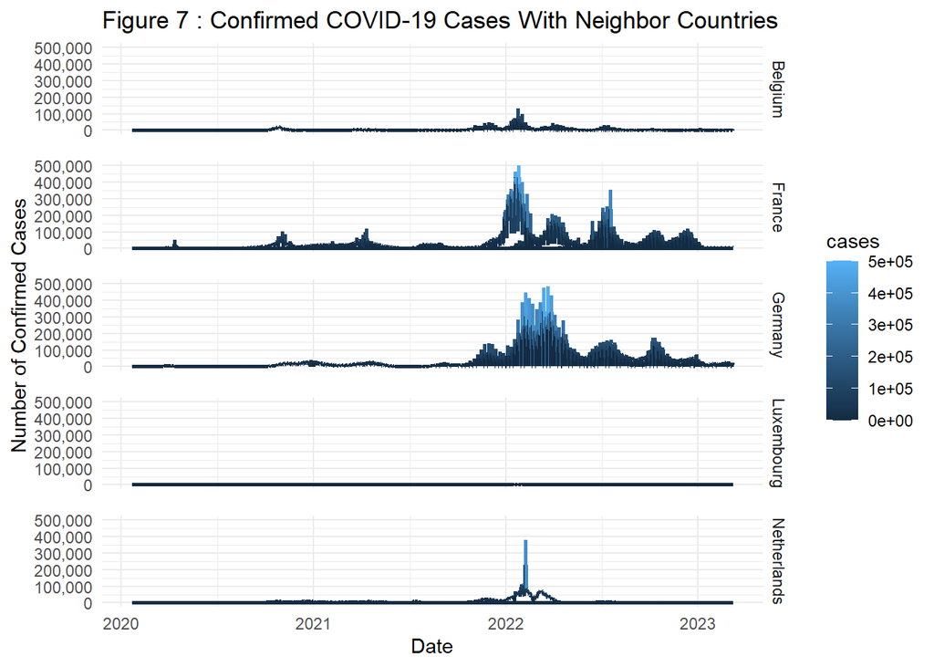

| country | population | mean | Total |
| --- | --- | --- | --- |
| Belgium | 11589616 | 4146.4261 | 4739365 |
| France | 5679311 | 2942.6415 | 40361271 |
| Germany | 83783945 | 33463.7445 | 38249060 |
| Luxembourg | 625976 | 278.8408 | 318715 |
| Netherlands | 3494968 | 1524.7050 | 8713689 |

The above figure 7 and table offer a comparative analysis of confirmed COVID-19 cases across five countries: Belgium, France, Germany, Luxembourg, and the Netherlands. The line graphs illustrate the daily confirmed cases from 2020 to 2023, while the table provides statistical summaries for each country, including population, average daily cases (mean), and total confirmed cases.

From the graphs, we can observe that the number of confirmed cases fluctuated significantly over time in each country. Germany and France show the highest peaks, indicating substantial outbreaks at various points during the pandemic. Belgium and the Netherlands also experienced significant peaks but to a lesser extent. Luxembourg, while not having zero cases, recorded much fewer cases compared to the other countries.

### 2.4.2 Death COVID-19 Cases Comparison

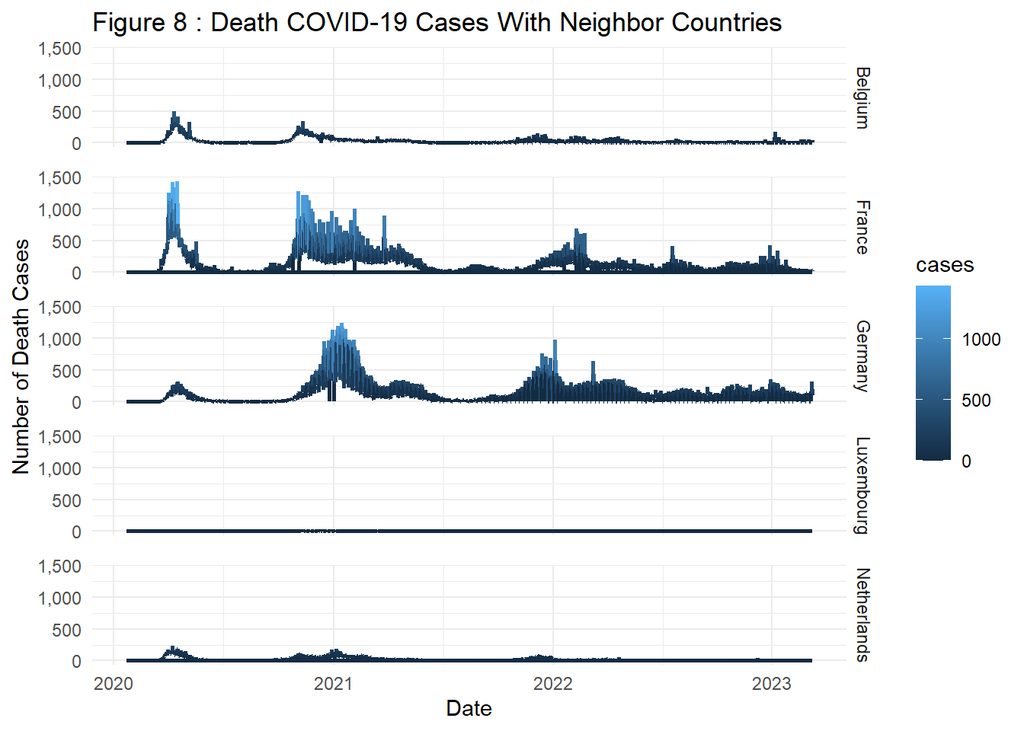

| country | population | mean | Total |
| --- | --- | --- | --- |
| Belgium | 11589616 | 29.685914 | 33931 |
| France | 5679311 | 12.155366 | 166723 |
| Germany | 83783945 | 147.807524 | 168944 |
| Luxembourg | 625976 | 1.069991 | 1223 |
| Netherlands | 3494968 | 4.162905 | 23791 |

### 2.4.3 Recovery COVID-19 Cases Comparison

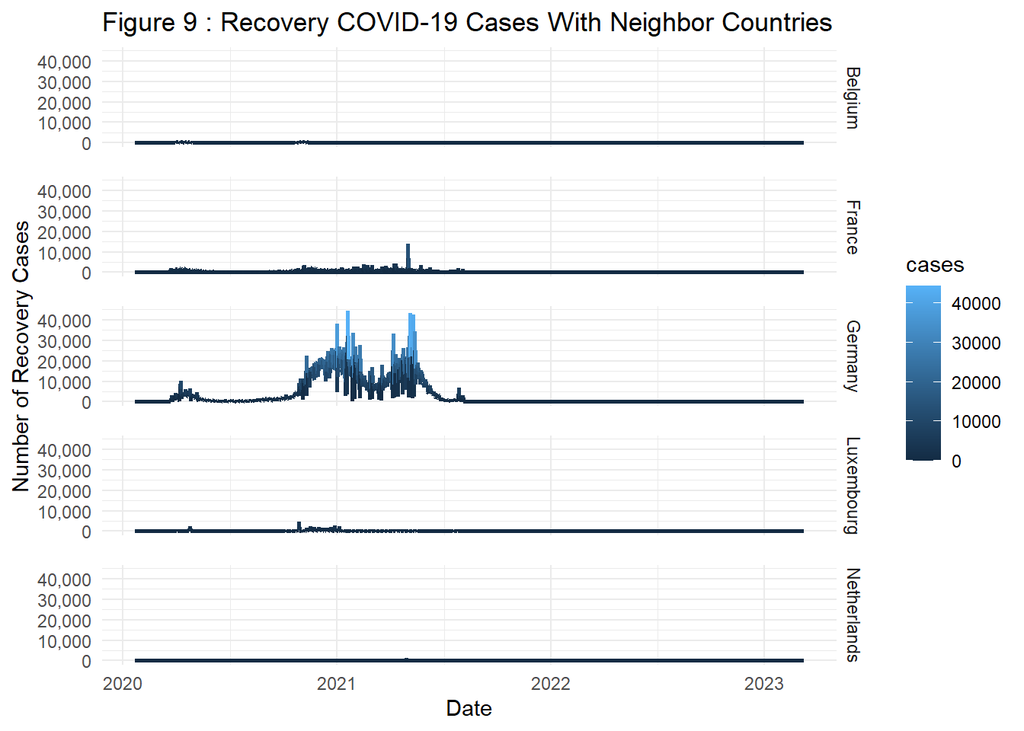

| country | population | mean | Total |
| --- | --- | --- | --- |
| Belgium | 11589616 | 27.307087 | 31212 |
| France | 5679311 | 31.292359 | 429206 |
| Germany | 83783945 | 3205.231846 | 3663580 |
| Luxembourg | 625976 | 68.252843 | 78013 |
| Netherlands | 3494968 | 5.035171 | 28776 |

Above charts shows a graph comparing COVID-19 recovery cases in five countries: Belgium, France, Germany, Luxembourg, and the Netherlands, from 2020 to 2023. Each country has a separate line graph displaying the number of daily recoveries. Germany had the highest number of recoveries, peaking around early 2021, while the other countries had much lower numbers. The table below the graph provides additional details, including each country’s population, the average number of recoveries per day (mean), and the total number of recoveries. Germany, with the largest population among the listed countries, also had the highest total number of recoveries at 3,663,580. In contrast, the Netherlands had the fewest recoveries, with a total of 28,776.

### 2.4.4 Active COVID-19 Cases Comparison

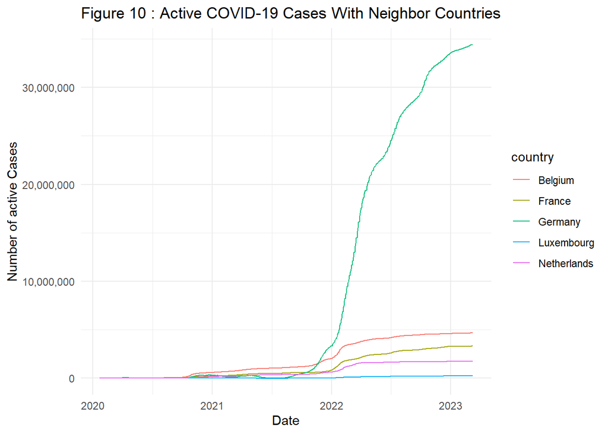

Figure 10 shows the number of active COVID-19 cases over time in Belgium and compares it with other countries: France, Germany, Luxembourg, and the Netherlands. From 2020 to 2023, the number of active cases increased significantly in all countries. Germany, represented by the green line, experienced the most substantial rise, particularly from late 2021 onwards, reaching over 30 million active cases. The other countries had much lower numbers of active cases. France and Belgium had moderate increases, while Luxembourg and the Netherlands had relatively small numbers of active cases throughout the period. The graph indicates that Germany faced a much larger burden of active COVID-19 cases compared to its neighboring countries during this time.

# 3.Discussion And Conclusion

# 4. References

- https://en.wikipedia.org/wiki/Belgium
- https://en.wikipedia.org/wiki/COVID-19_pandemic_in_Belgium